# Homework 3

Arman Manukyan

2025-03-09

```r
mobiles_dataset<- read.csv("mobiles_dataset.csv")
head(mobiles_dataset)
```

```
##   Company.Name           Model.Name Mobile.Weight RAM Front.Camera Back.Camera
## 1        Apple      iPhone 16 128GB          174g 6GB         12MP        48MP
## 2        Apple      iPhone 16 256GB          174g 6GB         12MP        48MP
## 3        Apple      iPhone 16 512GB          174g 6GB         12MP        48MP
## 4        Apple iPhone 16 Plus 128GB          203g 6GB         12MP        48MP
## 5        Apple iPhone 16 Plus 256GB          203g 6GB         12MP        48MP
## 6        Apple iPhone 16 Plus 512GB          203g 6GB         12MP        48MP
##    Processor Battery.Capacity.mAh Screen.Size.inches
## 1 A17 Bionic                 3600                6.1
## 2 A17 Bionic                 3600                6.1
## 3 A17 Bionic                 3600                6.1
## 4 A17 Bionic                 4200                6.7
## 5 A17 Bionic                 4200                6.7
## 6 A17 Bionic                 4200                6.7
##   Launched.Price.Pakistan.PKR Launched.Price.India.INR Launched.Price.China.CNY
## 1                      224999                    79999                     5799
## 2                      234999                    84999                     6099
## 3                      244999                    89999                     6499
## 4                      249999                    89999                     6199
## 5                      259999                    94999                     6499
## 6                      274999                   104999                     6999
##   Launched.Price.USA.USD Launched.Price.Dubai.AED Launched.Year
## 1                    799                     2799          2024
## 2                    849                     2999          2024
## 3                    899                     3199          2024
## 4                    899                     3199          2024
## 5                    949                     3399          2024
## 6                    999                     3599          2024
```

Part 1: Analytical Questions (Python & R) Hint: Convert all the currencies to dollars using the following logic: 1 PKR = 0.0036 USD 1 INR = 0.011 USD 1 CNY = 0.14 USD 1 AED = 0.27 USD

1.Does battery capacity influence the launched price of a smartphone? Check this variability across all currencies. Is there any type of difference between behaviors?

2.Does RAM size impact the price of smartphones? Check this variability across all currencies. Is there any type of difference between behaviors?

3.Do Apple devices have a higher price variation across different regions compared to other brands? In which country do Apple devices have the highest markup? Are there brands with more stable pricing across regions?

4.Do all smartphone brands have flagship and budget-friendly models, or do some brands only focus on premium devices? Hint: Categorize brands into budget, mid-range, and premium segments (Budget: < $300, Mid-range: $300 - $700, Premium: > $700). Check how many models each brand has in each segment. Determine whether a brand covers all three segments or focuses only on premium/mid-range.

5.Which region offers the most affordable smartphone prices on average? Are there any brands that price their phones significantly lower in one region compared to others?

```r
mobiles_dataset <- mobiles_dataset %>%
  mutate(
    Launched.Price.USA.USD = Launched.Price.USA.USD,
    Launched.Price.Pakistan.PKR = Launched.Price.Pakistan.PKR * 0.0036,
    Launched.Price.India.INR = Launched.Price.India.INR * 0.011,
    Launched.Price.China.CNY = Launched.Price.China.CNY * 0.14,
    Launched.Price.Dubai.AED = Launched.Price.Dubai.AED * 0.27
  )

head(mobiles_dataset)
```

```
##   Company.Name           Model.Name Mobile.Weight RAM Front.Camera Back.Camera
## 1        Apple      iPhone 16 128GB          174g 6GB         12MP        48MP
## 2        Apple      iPhone 16 256GB          174g 6GB         12MP        48MP
## 3        Apple      iPhone 16 512GB          174g 6GB         12MP        48MP
## 4        Apple iPhone 16 Plus 128GB          203g 6GB         12MP        48MP
## 5        Apple iPhone 16 Plus 256GB          203g 6GB         12MP        48MP
## 6        Apple iPhone 16 Plus 512GB          203g 6GB         12MP        48MP
##    Processor Battery.Capacity.mAh Screen.Size.inches
## 1 A17 Bionic                 3600                6.1
## 2 A17 Bionic                 3600                6.1
## 3 A17 Bionic                 3600                6.1
## 4 A17 Bionic                 4200                6.7
## 5 A17 Bionic                 4200                6.7
## 6 A17 Bionic                 4200                6.7
##   Launched.Price.Pakistan.PKR Launched.Price.India.INR Launched.Price.China.CNY
## 1                    809.9964                  879.989                   811.86
## 2                    845.9964                  934.989                   853.86
## 3                    881.9964                  989.989                   909.86
## 4                    899.9964                  989.989                   867.86
## 5                    935.9964                 1044.989                   909.86
## 6                    989.9964                 1154.989                   979.86
##   Launched.Price.USA.USD Launched.Price.Dubai.AED Launched.Year
## 1                    799                   755.73          2024
## 2                    849                   809.73          2024
## 3                    899                   863.73          2024
## 4                    899                   863.73          2024
## 5                    949                   917.73          2024
## 6                    999                   971.73          2024
```

1.Does battery capacity influence the launched price of a smartphone? Check this variability across all currencies. Is there any type of difference between behaviors?

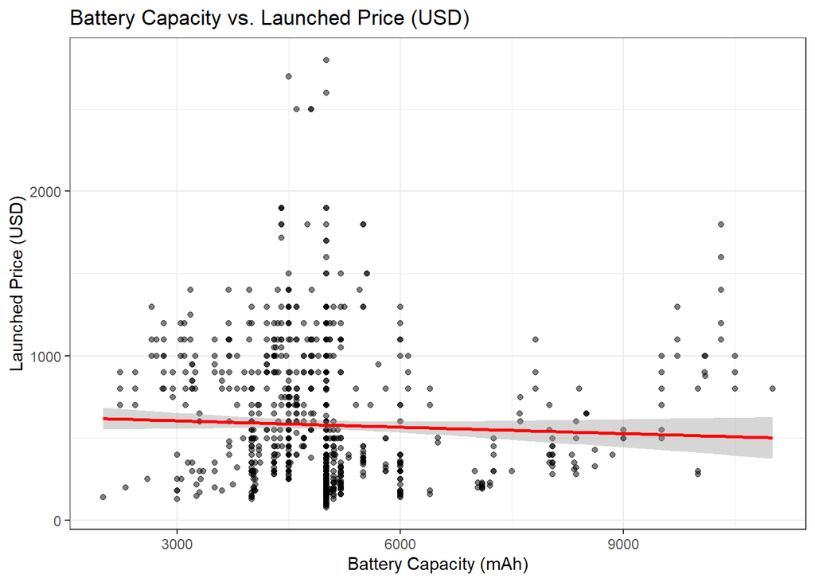

```r
ggplot(mobiles_dataset, aes(x = Battery.Capacity.mAh, y = Launched.Price.USA.USD)) +
  geom_point(alpha = 0.5) +
  geom_smooth(method = "lm", col = "red") +
  labs(title = "Battery Capacity vs. Launched Price (USD)",
       x = "Battery Capacity (mAh)",
       y = "Launched Price (USD)") +
  theme_bw()
```

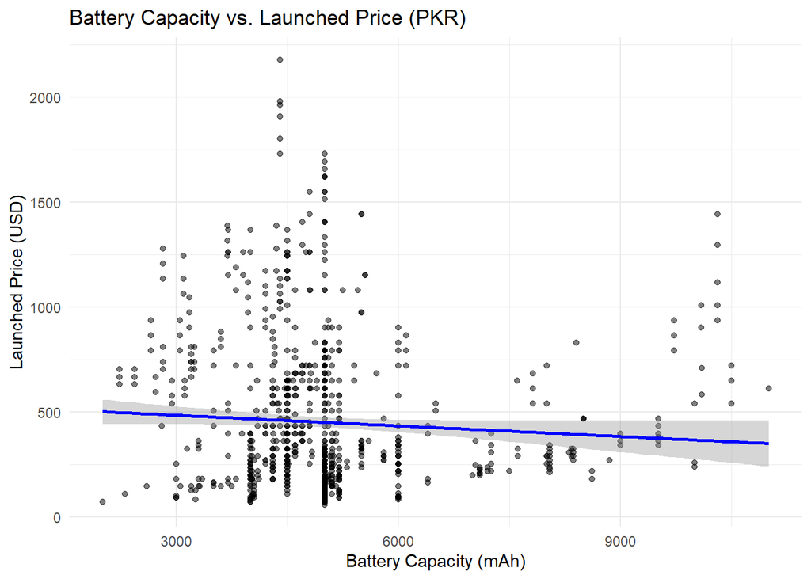

```r
ggplot(mobiles_dataset, aes(x = Battery.Capacity.mAh, y = Launched.Price.Pakistan.PKR)) +
  geom_point(alpha = 0.5) +
  geom_smooth(method = "lm", col = "blue") +
  labs(title = "Battery Capacity vs. Launched Price (PKR)",
       x = "Battery Capacity (mAh)",
       y = "Launched Price (USD)") +
  theme_minimal()
```

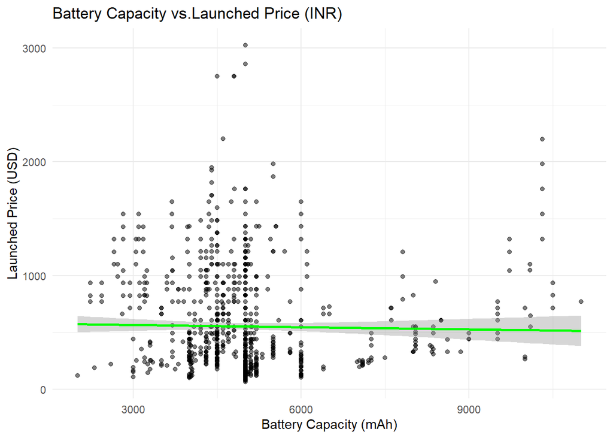

```r
ggplot(mobiles_dataset, aes(x = Battery.Capacity.mAh, y = Launched.Price.India.INR)) +
  geom_point(alpha = 0.5) +
  geom_smooth(method = "lm", col = "green") +
  labs(title = "Battery Capacity vs.Launched Price (INR)",
       x = "Battery Capacity (mAh)",
       y = "Launched Price (USD)") +
  theme_minimal()
```

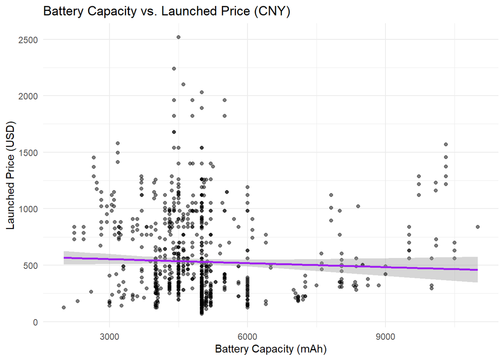

```r
ggplot(mobiles_dataset, aes(x = Battery.Capacity.mAh, y = Launched.Price.China.CNY)) +
  geom_point(alpha = 0.5) +
  geom_smooth(method = "lm", col = "purple") +
  labs(title = "Battery Capacity vs. Launched Price (CNY)",
       x = "Battery Capacity (mAh)",
       y = "Launched Price (USD)") +
  theme_minimal()
```

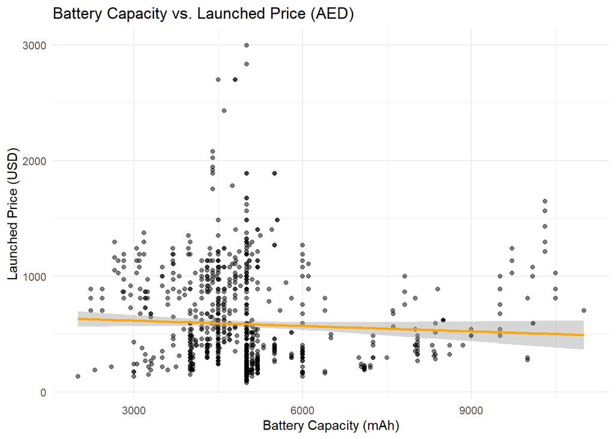

```r
ggplot(mobiles_dataset, aes(x = Battery.Capacity.mAh, y = Launched.Price.Dubai.AED)) +
  geom_point(alpha = 0.5) +
  geom_smooth(method = "lm", col = "orange") +
  labs(title = "Battery Capacity vs. Launched Price (AED)",
       x = "Battery Capacity (mAh)",
       y = "Launched Price (USD)") +
  theme_minimal()
```

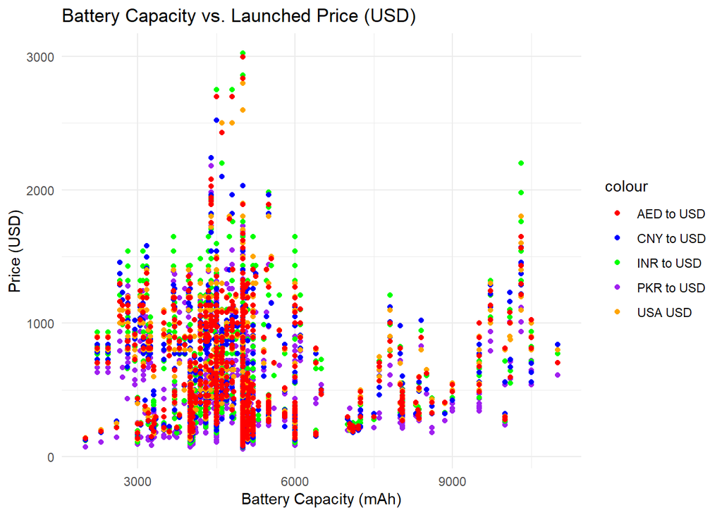

```r
ggplot(mobiles_dataset, aes(x = Battery.Capacity.mAh)) +
  geom_point(aes(y = Launched.Price.Pakistan.PKR, color = "PKR to USD")) +
  geom_point(aes(y = Launched.Price.India.INR, color = "INR to USD")) +
  geom_point(aes(y = Launched.Price.China.CNY, color = "CNY to USD")) +
  geom_point(aes(y = Launched.Price.USA.USD, color = "USA USD")) +
  geom_point(aes(y = Launched.Price.Dubai.AED, color = "AED to USD")) +
  labs(title = "Battery Capacity vs. Launched Price (USD)", x = "Battery Capacity (mAh)", y = "Price (USD)") +
  theme_minimal() +
  scale_color_manual(values = c("red", "blue", "green", "purple", "orange"))
```

```r
correlations <- mobiles_dataset %>%
  select(Battery.Capacity.mAh, Launched.Price.Pakistan.PKR,  Launched.Price.India.INR, Launched.Price.China.CNY, Launched.Price.Dubai.AED, `Launched.Price.USA.USD`) %>%
  cor(use = "complete.obs")
print(correlations)
```

```
##                             Battery.Capacity.mAh Launched.Price.Pakistan.PKR
## Battery.Capacity.mAh                  1.00000000                 -0.06091272
## Launched.Price.Pakistan.PKR          -0.06091272                  1.00000000
## Launched.Price.India.INR             -0.01905429                  0.90383120
## Launched.Price.China.CNY             -0.04104334                  0.90235380
## Launched.Price.Dubai.AED             -0.04890776                  0.89856277
## Launched.Price.USA.USD               -0.04113680                  0.89773898
##                             Launched.Price.India.INR Launched.Price.China.CNY
## Battery.Capacity.mAh                     -0.01905429              -0.04104334
## Launched.Price.Pakistan.PKR               0.90383120               0.90235380
## Launched.Price.India.INR                  1.00000000               0.96719396
## Launched.Price.China.CNY                  0.96719396               1.00000000
## Launched.Price.Dubai.AED                  0.96895235               0.96929083
## Launched.Price.USA.USD                    0.96913458               0.96820319
##                             Launched.Price.Dubai.AED Launched.Price.USA.USD
## Battery.Capacity.mAh                     -0.04890776             -0.0411368
## Launched.Price.Pakistan.PKR               0.89856277              0.8977390
## Launched.Price.India.INR                  0.96895235              0.9691346
## Launched.Price.China.CNY                  0.96929083              0.9682032
## Launched.Price.Dubai.AED                  1.00000000              0.9902623
## Launched.Price.USA.USD                    0.99026235              1.0000000
```

Findings from the Graphs and analysis : *The scatter plots show a very weak or no clear correlation between Battery Capacity (mAh) and Price (USD).* The trend lines (regression lines) in each graph are almost flat or slightly declining, meaning battery capacity does not significantly influence price. *Regardless of the currency (PKR, INR, CNY, AED, USD all converted to USD , the trend remains similar—battery capacity does not seem to be a strong determinant of price.

Variability across all currencies

*The trend appears consistent across all currencies (converted to USD).* Some outliers exist, where phones with smaller batteries have high prices (likely due to premium brands or advanced features). The price distribution is quite scattered, confirming that other factors besides battery capacity (such as brand, camera, and processor) influence smartphone pricing more significantly.

Conclusion: Battery capacity does NOT strongly influence the launched price of a smartphone. The trend is consistent across different currencies, meaning battery size does not impact pricing differently in different regions.

2.Does RAM size impact the price of smartphones? Check this variability across all currencies. Is there any type of difference between behaviors?

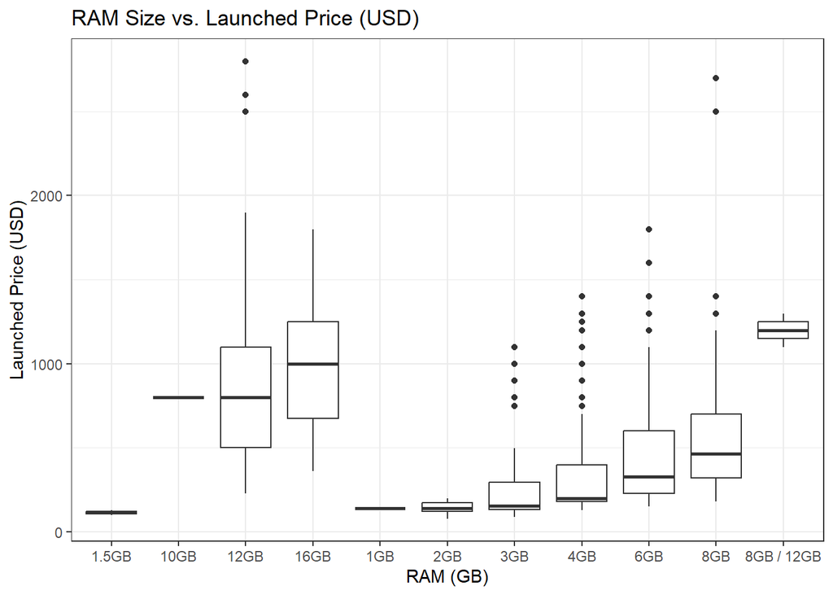

```r
ggplot(mobiles_dataset, aes(x = RAM, y = Launched.Price.USA.USD)) +
  geom_boxplot() +
  labs(title = "RAM Size vs. Launched Price (USD)",
       x = "RAM (GB)",
       y = "Launched Price (USD)") +
  theme_bw()
```

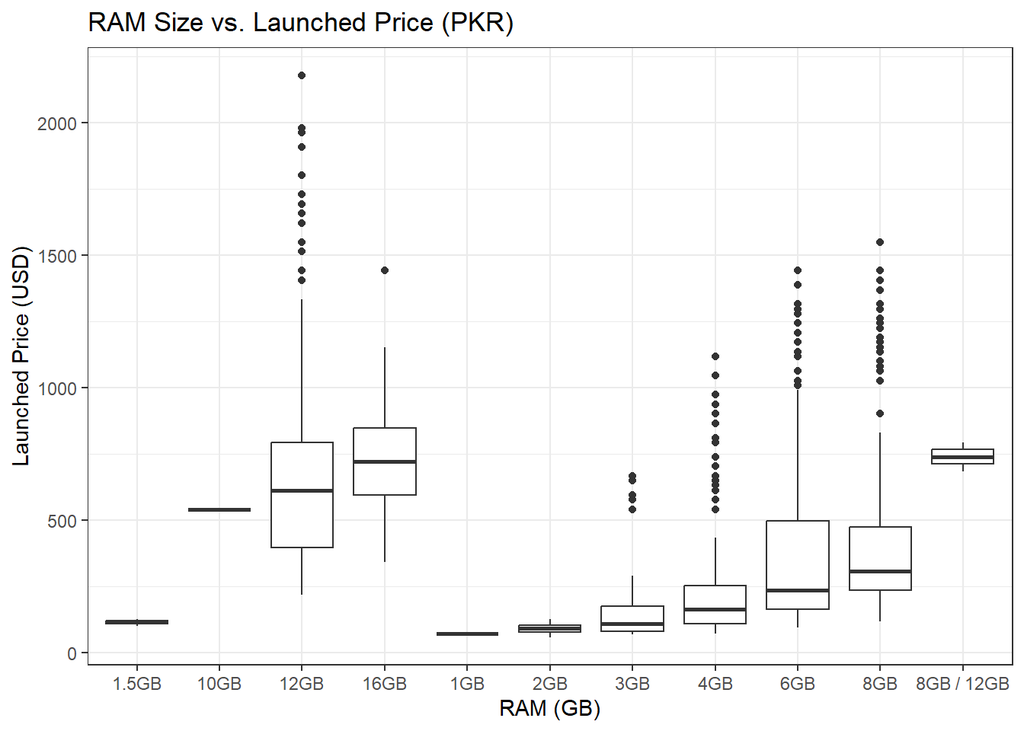

```r
ggplot(mobiles_dataset, aes(x = RAM, y = Launched.Price.Pakistan.PKR)) +
  geom_boxplot() +
  labs(title = "RAM Size vs. Launched Price (PKR)",
       x = "RAM (GB)",
       y = "Launched Price (USD)") +
  theme_bw()
```

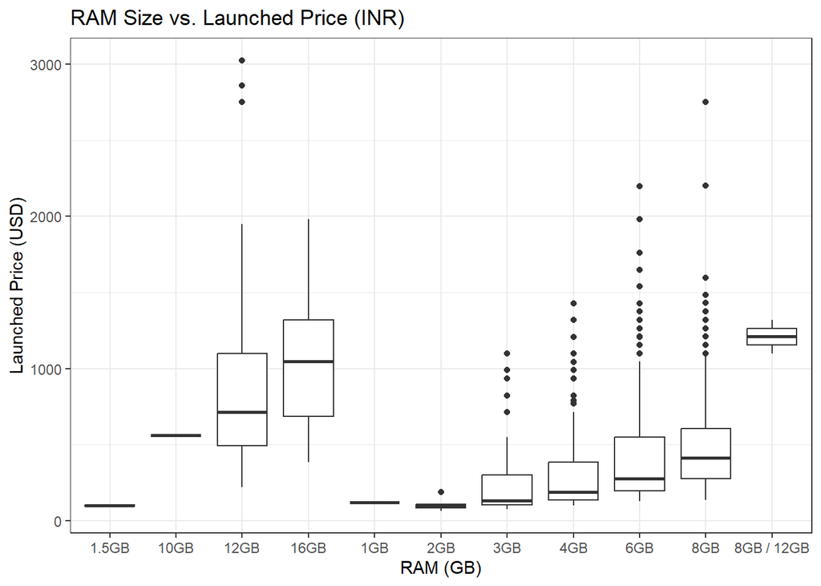

```r
ggplot(mobiles_dataset, aes(x = RAM, y = Launched.Price.India.INR)) +
  geom_boxplot() +
  labs(title = "RAM Size vs. Launched Price (INR)",
       x = "RAM (GB)",
       y = "Launched Price (USD)") +
  theme_bw()
```

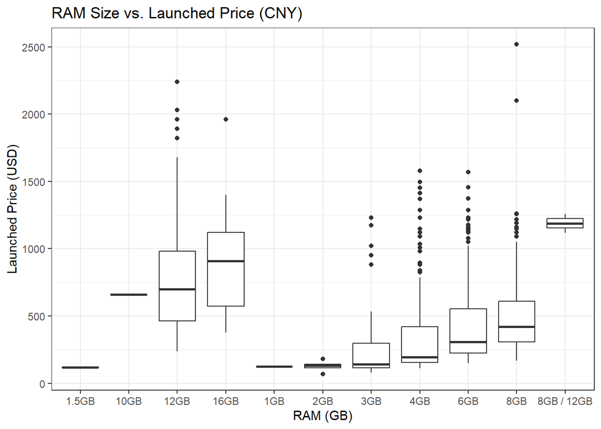

```r
ggplot(mobiles_dataset, aes(x = RAM, y = Launched.Price.China.CNY)) +
  geom_boxplot() +
  labs(title = "RAM Size vs. Launched Price (CNY)",
       x = "RAM (GB)",
       y = "Launched Price (USD)") +
  theme_bw()
```

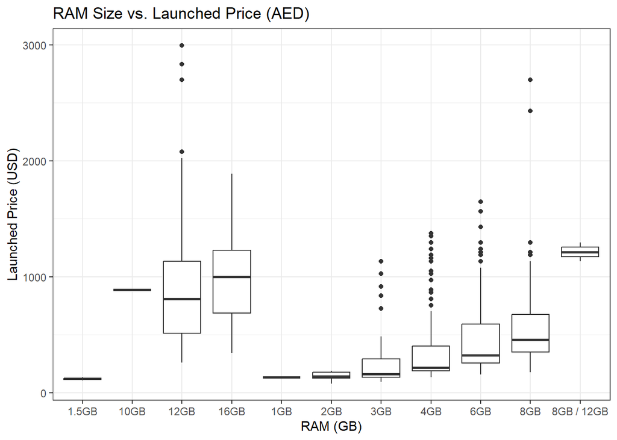

```r
ggplot(mobiles_dataset, aes(x = RAM, y = Launched.Price.Dubai.AED)) +
  geom_boxplot() +

  labs(title = "RAM Size vs. Launched Price (AED)",
       x = "RAM (GB)",
       y = "Launched Price (USD)") +
  theme_bw()
```

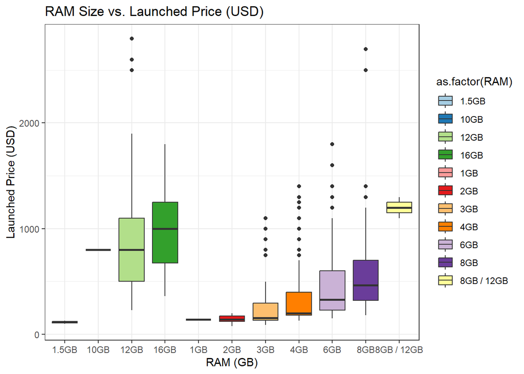

```r
library(ggplot2)

ggplot(mobiles_dataset, aes(x = as.factor(RAM), y = Launched.Price.USA.USD, fill = as.factor(RAM))) +
  geom_boxplot() +
  scale_fill_brewer(palette = "Paired") +
  labs(title = "RAM Size vs. Launched Price (USD)",
       x = "RAM (GB)",
       y = "Launched Price (USD)") +
  theme_bw()
```

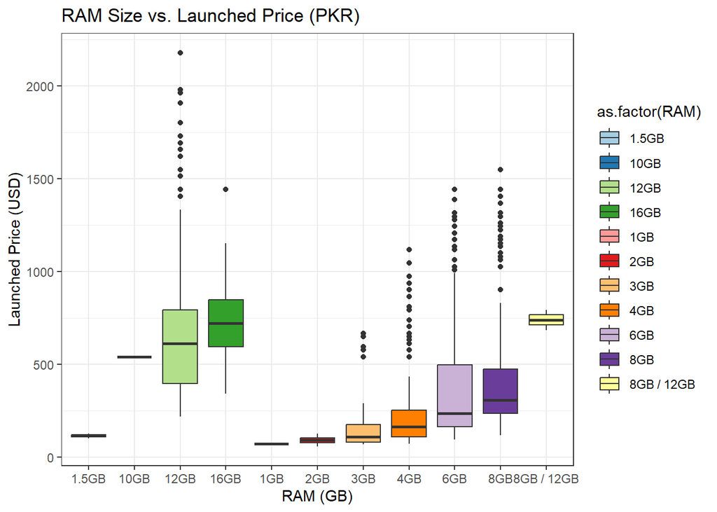

```r
ggplot(mobiles_dataset, aes(x = as.factor(RAM), y = Launched.Price.Pakistan.PKR, fill = as.factor(RAM))) +
  geom_boxplot() +
  scale_fill_brewer(palette = "Paired") +
  labs(title = "RAM Size vs. Launched Price (PKR)",
       x = "RAM (GB)",
       y = "Launched Price (USD)") +
  theme_bw()
```

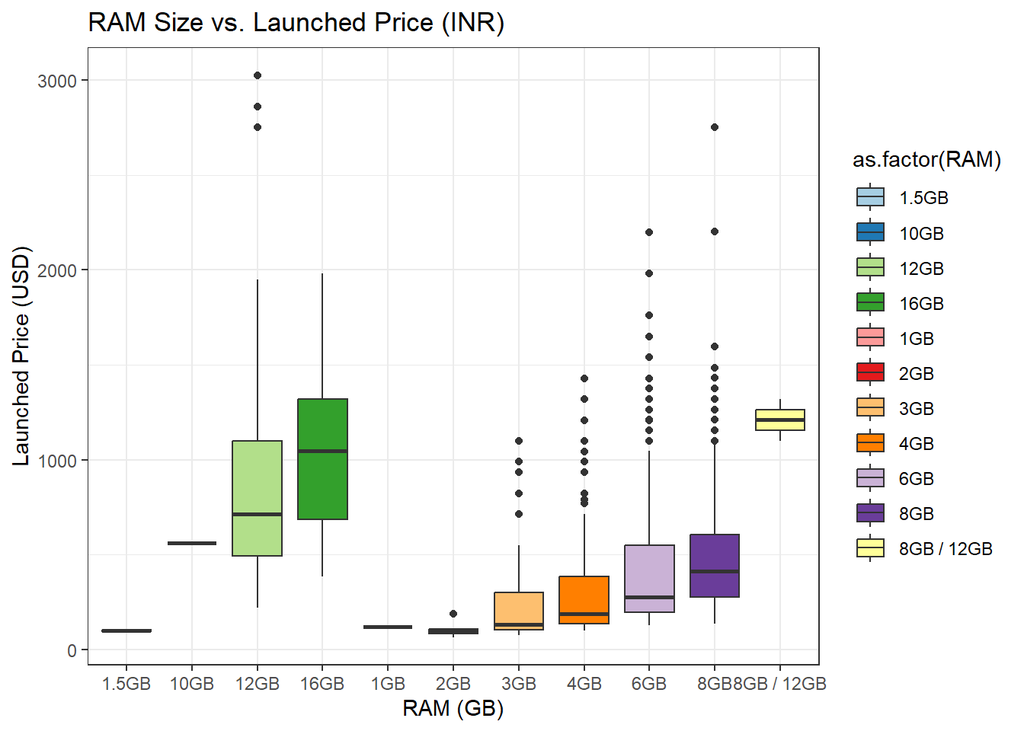

```r
ggplot(mobiles_dataset, aes(x = as.factor(RAM), y = Launched.Price.India.INR, fill = as.factor(RAM))) +
  geom_boxplot() +
  scale_fill_brewer(palette = "Paired") +
  labs(title = "RAM Size vs. Launched Price (INR)",
       x = "RAM (GB)",
       y = "Launched Price (USD)") +
  theme_bw()
```

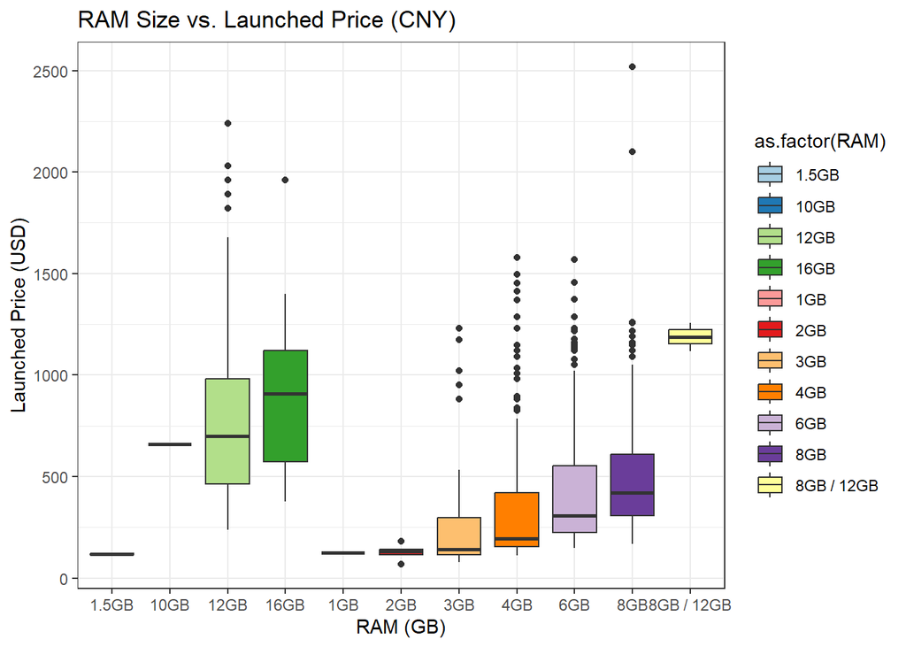

```r
ggplot(mobiles_dataset, aes(x = as.factor(RAM), y = Launched.Price.China.CNY, fill = as.factor(RAM))) +
  geom_boxplot() +
  scale_fill_brewer(palette = "Paired") +
  labs(title = "RAM Size vs. Launched Price (CNY)",
       x = "RAM (GB)",
       y = "Launched Price (USD)") +
  theme_bw()
```

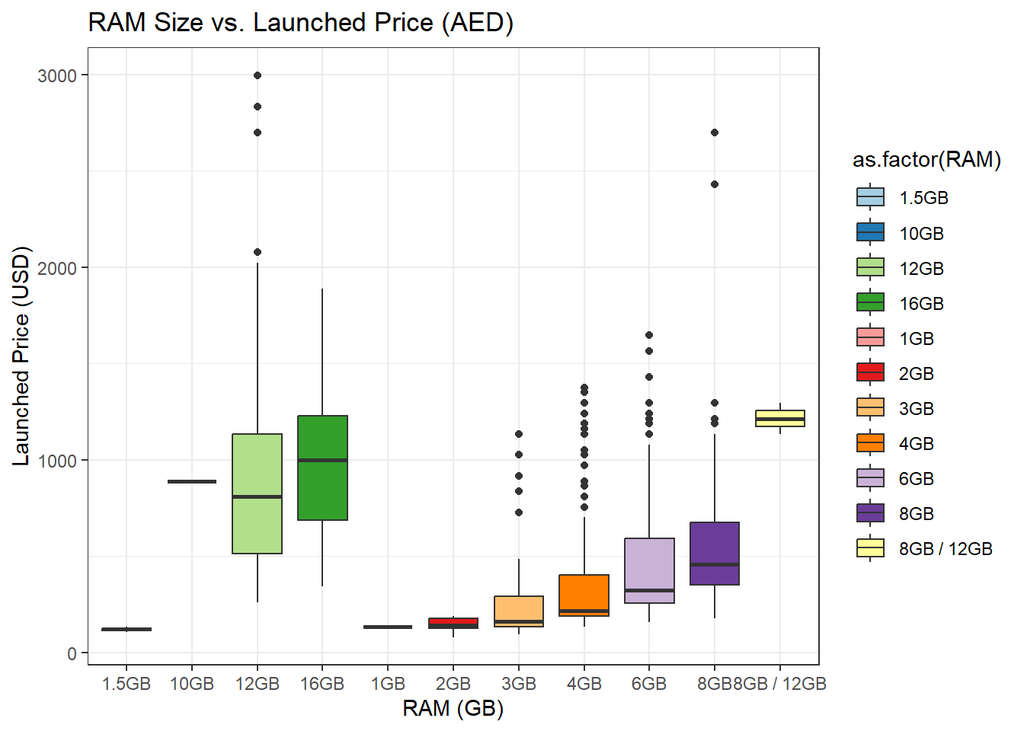

```r
ggplot(mobiles_dataset, aes(x = as.factor(RAM), y = Launched.Price.Dubai.AED, fill = as.factor(RAM))) +
  geom_boxplot() +
  scale_fill_brewer(palette = "Paired") +
  labs(title = "RAM Size vs. Launched Price (AED)",
       x = "RAM (GB)",
       y = "Launched Price (USD)") +
  theme_bw()
```

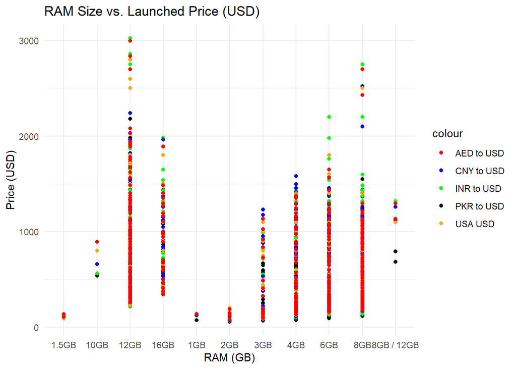

```r
ggplot(mobiles_dataset, aes(x = RAM)) +
  geom_point(aes(y = Launched.Price.Pakistan.PKR, color = "PKR to USD")) +
  geom_point(aes(y = Launched.Price.India.INR, color = "INR to USD")) +
  geom_point(aes(y = Launched.Price.China.CNY, color = "CNY to USD")) +
  geom_point(aes(y = Launched.Price.USA.USD, color = "USA USD")) +
  geom_point(aes(y = Launched.Price.Dubai.AED, color = "AED to USD")) +
  labs(title = "RAM Size vs. Launched Price (USD)", x = "RAM (GB)", y = "Price (USD)") +
  theme_minimal() +
  scale_color_manual(values = c("red", "blue", "green", "black", "orange"))
```

```r
str(mobiles_dataset)
```

```
## 'data.frame':    925 obs. of  15 variables:
##  $ Company.Name               : chr  "Apple" "Apple" "Apple" "Apple" ...
##  $ Model.Name                 : chr  "iPhone 16 128GB" "iPhone 16 256GB" "iPhone 16 512GB" "iPhone 16 Plus 128GB" ...
##  $ Mobile.Weight              : chr  "174g" "174g" "174g" "203g" ...
##  $ RAM                        : chr  "6GB" "6GB" "6GB" "6GB" ...
##  $ Front.Camera               : chr  "12MP" "12MP" "12MP" "12MP" ...
##  $ Back.Camera                : chr  "48MP" "48MP" "48MP" "48MP" ...
##  $ Processor                  : chr  "A17 Bionic" "A17 Bionic" "A17 Bionic" "A17 Bionic" ...
##  $ Battery.Capacity.mAh       : int  3600 3600 3600 4200 4200 4200 4400 4400 4400 4500 ...
##  $ Screen.Size.inches         : num  6.1 6.1 6.1 6.7 6.7 6.7 6.1 6.1 6.1 6.7 ...
##  $ Launched.Price.Pakistan.PKR: num  810 846 882 900 936 ...
##  $ Launched.Price.India.INR   : num  880 935 990 990 1045 ...
##  $ Launched.Price.China.CNY   : num  812 854 910 868 910 ...
##  $ Launched.Price.USA.USD     : int  799 849 899 899 949 999 999 1049 1099 1099 ...
##  $ Launched.Price.Dubai.AED   : num  756 810 864 864 918 ...
##  $ Launched.Year              : int  2024 2024 2024 2024 2024 2024 2024 2024 2024 2024 ...
```

```r
mobiles_dataset <- mobiles_dataset %>%
  mutate(RAM = as.numeric(gsub("GB", "", RAM)))
correlations <- mobiles_dataset %>%
  select(RAM, Launched.Price.Pakistan.PKR, Launched.Price.India.INR,
         Launched.Price.China.CNY, Launched.Price.Dubai.AED, `Launched.Price.USA.USD`) %>%
  cor(use = "complete.obs")
print(correlations)
```

```
##                                   RAM Launched.Price.Pakistan.PKR
## RAM                         1.0000000                   0.4091150
## Launched.Price.Pakistan.PKR 0.4091150                   1.0000000
## Launched.Price.India.INR    0.4169188                   0.9040471
## Launched.Price.China.CNY    0.4227330                   0.9029307
## Launched.Price.Dubai.AED    0.4739097                   0.8987959
## Launched.Price.USA.USD      0.4628016                   0.8979527
##                             Launched.Price.India.INR Launched.Price.China.CNY
## RAM                                        0.4169188                0.4227330
## Launched.Price.Pakistan.PKR                0.9040471                0.9029307
## Launched.Price.India.INR                   1.0000000                0.9670840
## Launched.Price.China.CNY                   0.9670840                1.0000000
## Launched.Price.Dubai.AED                   0.9688035                0.9691688
## Launched.Price.USA.USD                     0.9689838                0.9680884
##                             Launched.Price.Dubai.AED Launched.Price.USA.USD
## RAM                                        0.4739097              0.4628016
## Launched.Price.Pakistan.PKR                0.8987959              0.8979527
## Launched.Price.India.INR                   0.9688035              0.9689838
## Launched.Price.China.CNY                   0.9691688              0.9680884
## Launched.Price.Dubai.AED                   1.0000000              0.9902166
## Launched.Price.USA.USD                     0.9902166              1.0000000
```

From the boxplots,I observe that smartphones with lower RAM (1GB–3GB) are considerably cheaper, whereas devices with higher RAM (8GB, 12GB, and 16GB) are significantly more expensive. Additionally, the price variability increases as RAM size increases, suggesting that higher RAM devices often belong to premium flagship categories, which include additional features such as better processors, superior camera systems, and enhanced display technologies.

While the overall pattern remains the same across different currencies, there are some variations in pricing behavior. Prices in USD appear more stable, whereas PKR, INR, and CNY show greater dispersion, likely due to regional pricing strategies, import duties, and currency fluctuations. The wider interquartile range (IQR) for higher RAM models suggests that certain brands price their flagship devices significantly higher than others. Moreover, outliers exist at both low and high RAM levels, indicating that some budget devices have unexpectedly high prices, while some flagship devices reach premium price points.

3.Do Apple devices have a higher price variation across different regions compared to other brands? In which country do Apple devices have the highest markup? Are there brands with more stable pricing across regions?

```r
colnames(mobiles_dataset)
```

```
##  [1] "Company.Name"                "Model.Name"
##  [3] "Mobile.Weight"               "RAM"
##  [5] "Front.Camera"                "Back.Camera"
##  [7] "Processor"                   "Battery.Capacity.mAh"
##  [9] "Screen.Size.inches"          "Launched.Price.Pakistan.PKR"
## [11] "Launched.Price.India.INR"    "Launched.Price.China.CNY"
## [13] "Launched.Price.USA.USD"      "Launched.Price.Dubai.AED"
## [15] "Launched.Year"
```

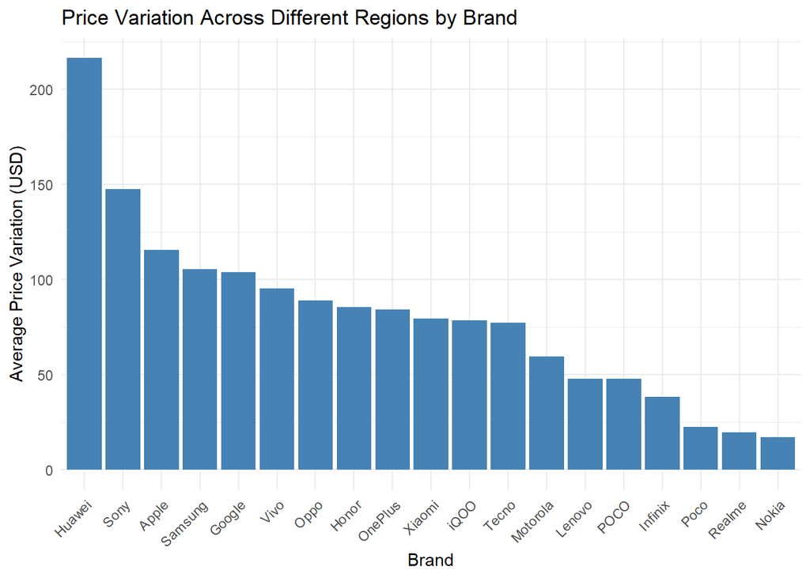

```r
price_columns <- c(
  "Launched.Price.Pakistan.PKR",
  "Launched.Price.India.INR",
  "Launched.Price.USA.USD",
  "Launched.Price.China.CNY",
  "Launched.Price.Dubai.AED"
)

mobiles_dataset$Price_Variation <- apply(mobiles_dataset[, price_columns], 1, sd, na.rm = TRUE)

brand_variation <- mobiles_dataset %>%
  group_by(Company.Name) %>%
  summarise(Average_Price_Variation = mean(Price_Variation, na.rm = TRUE)) %>%
  arrange(desc(Average_Price_Variation))

ggplot(brand_variation, aes(x = reorder(Company.Name, -Average_Price_Variation), y = Average_Price_Variation)) +
  geom_bar(stat = "identity", fill = "steelblue") +
  theme_minimal() +
  labs(x = "Brand", y = "Average Price Variation (USD)", title = "Price Variation Across Different Regions by Brand") +
  theme(axis.text.x = element_text(angle = 45, hjust = 1))
```

```r
apple_prices <- mobiles_dataset %>%
  filter(Company.Name == "Apple") %>%
  summarise(across(all_of(price_columns), mean, na.rm = TRUE))

apple_markup <- (apple_prices - apple_prices$Launched.Price.USA.USD) / apple_prices$Launched.Price.USA.USD * 100

highest_markup_country <- names(which.max(apple_markup))
highest_markup_value <- max(apple_markup, na.rm = TRUE)

cat("Country with the highest markup for Apple devices:", highest_markup_country, "\n")
```

```
## Country with the highest markup for Apple devices: Launched.Price.India.INR
```

```r
cat("Highest markup percentage:", highest_markup_value, "%", "\n")
```

```
## Highest markup percentage: 10.16058 %
```

```r
stable_brands <- brand_variation %>%
  arrange(Average_Price_Variation) %>%
  head(5)

print(stable_brands)
```

```
## # A tibble: 5 × 2
##   Company.Name Average_Price_Variation
##   <chr>                          <dbl>
## 1 Nokia                           16.9
## 2 Realme                          19.6
## 3 Poco                            22.4
## 4 Infinix                         38.1
## 5 POCO                            47.6
```

Apple devices do exhibit a high price variation across regions, but they are not the highest. Huawei has the highest average price variation among brands. Apple ranks among the top brands with significant price differences across regions. From the price variation data, Apple’s average price variation is lower than Huawei but higher than many other brands. The visualization confirms that Apple has one of the most fluctuating prices globally, though not the most extreme.

In which country do Apple devices have the highest markup?

The highest markup for Apple devices occurs in India.

The markup percentage in India is 10.16%, which is the highest among all regions. This suggests that Apple products are priced significantly higher in India compared to their base price in the USA. Are there brands with more stable pricing across regions? Yes, some brands have much more stable pricing across different regions.

Nokia has the lowest price variation, with an average of 16.93 USD, making it the most stable brand. Other brands with relatively stable pricing include Realme, Poco, Infinix, and POCO, all of which have lower price fluctuations compared to Apple.